# client_deposit

```python
import warnings
warnings.filterwarnings('ignore')
from IPython.core.interactiveshell import InteractiveShell
InteractiveShell.ast_node_interactivity="all"
```

```python
import numpy as np
import pandas as pd
import matplotlib.pyplot as plt
import seaborn as sns
sns.set(color_codes=True)
%matplotlib inline
```

```python
client_data=pd.read_csv("bank-full.csv")
```

```python
client_data.head(10)
```

|  | age | job | marital | education | default | balance | housing | loan | contact | day | month | duration | campaign | pdays | previous | poutcome | Target |
| --- | --- | --- | --- | --- | --- | --- | --- | --- | --- | --- | --- | --- | --- | --- | --- | --- | --- |
| 0 | 58 | management | married | tertiary | no | 2143 | yes | no | unknown | 5 | may | 261 | 1 | -1 | 0 | unknown | no |
| 1 | 44 | technician | single | secondary | no | 29 | yes | no | unknown | 5 | may | 151 | 1 | -1 | 0 | unknown | no |
| 2 | 33 | entrepreneur | married | secondary | no | 2 | yes | yes | unknown | 5 | may | 76 | 1 | -1 | 0 | unknown | no |
| 3 | 47 | blue-collar | married | unknown | no | 1506 | yes | no | unknown | 5 | may | 92 | 1 | -1 | 0 | unknown | no |
| 4 | 33 | unknown | single | unknown | no | 1 | no | no | unknown | 5 | may | 198 | 1 | -1 | 0 | unknown | no |
| 5 | 35 | management | married | tertiary | no | 231 | yes | no | unknown | 5 | may | 139 | 1 | -1 | 0 | unknown | no |
| 6 | 28 | management | single | tertiary | no | 447 | yes | yes | unknown | 5 | may | 217 | 1 | -1 | 0 | unknown | no |
| 7 | 42 | entrepreneur | divorced | tertiary | yes | 2 | yes | no | unknown | 5 | may | 380 | 1 | -1 | 0 | unknown | no |
| 8 | 58 | retired | married | primary | no | 121 | yes | no | unknown | 5 | may | 50 | 1 | -1 | 0 | unknown | no |
| 9 | 43 | technician | single | secondary | no | 593 | yes | no | unknown | 5 | may | 55 | 1 | -1 | 0 | unknown | no |

```python
client_data.dtypes
```

```
age           int64
job          object
marital      object
education    object
default      object
balance       int64
housing      object
loan         object
contact      object
day           int64
month        object
duration      int64
campaign      int64
pdays         int64
previous      int64
poutcome     object
Target       object
dtype: object
```

```python
client_data.shape
```

```
(45211, 17)
```

```python
client_data.isnull().sum()
```

```
age          0
job          0
marital      0
education    0
default      0
balance      0
housing      0
loan         0
contact      0
day          0
month        0
duration     0
campaign     0
pdays        0
previous     0
poutcome     0
Target       0
dtype: int64
```

```python
categories=['job', 'marital', 'education', 'default', 'housing', 'loan', 'contact', 'month', 'poutcome', 'Target']
for c in categories:
    print(f"\nValue counts for category {c}")
    print(client_data[c].value_counts())
```

```
Value counts for category job
blue-collar      9732
management       9458
technician       7597
admin.           5171
services         4154
retired          2264
self-employed    1579
entrepreneur     1487
unemployed       1303
housemaid        1240
student           938
unknown           288
Name: job, dtype: int64

Value counts for category marital
married     27214
single      12790
divorced     5207
Name: marital, dtype: int64

Value counts for category education
secondary    23202
tertiary     13301
primary       6851
unknown       1857
Name: education, dtype: int64

Value counts for category default
no     44396
yes      815
Name: default, dtype: int64

Value counts for category housing
yes    25130
no     20081
Name: housing, dtype: int64

Value counts for category loan
no     37967
```

[output cut: 20 more lines]

```
mar      477
dec      214
Name: month, dtype: int64

Value counts for category poutcome
unknown    36959
failure     4901
other       1840
success     1511
Name: poutcome, dtype: int64

Value counts for category Target
no     39922
yes     5289
Name: Target, dtype: int64
```

```python
# Replace unknown values in cateogrical columns with the mode.
for c in ['job', 'education', 'contact']:
    column_mode=client_data[c].mode().iloc[0]
    print(f"Replacing unknown in column {c} with the mode {column_mode}")
    client_data[c].replace(to_replace='unknown', value=column_mode, inplace=True)
print("For column poutcome, the most common is 'unknown'. Replace it with failure")
client_data['poutcome'].replace(to_replace='unknown', value='failure', inplace=True)
```

```
Replacing unknown in column job with the mode blue-collar
Replacing unknown in column education with the mode secondary
Replacing unknown in column contact with the mode cellular
For column poutcome, the most common is 'unknown'. Replace it with failure
```

```python
# For Target value, we need 0 or 1 to look at correlation.
client_data['Target'].replace(to_replace='no', value=0, inplace=True)
client_data['Target'].replace(to_replace='yes', value=1, inplace=True)
client_data['Target']=client_data['Target'].astype("int")
```

```python
categories=['job', 'marital', 'education', 'default', 'housing', 'loan', 'contact', 'month', 'poutcome']
for c in categories:
    client_data[c]=client_data[c].astype("category")
    print(f"\nValue counts for category {c}")
    print(client_data[c].value_counts())
```

```
Value counts for category job
blue-collar      10020
management        9458
technician        7597
admin.            5171
services          4154
retired           2264
self-employed     1579
entrepreneur      1487
unemployed        1303
housemaid         1240
student            938
Name: job, dtype: int64

Value counts for category marital
married     27214
single      12790
divorced     5207
Name: marital, dtype: int64

Value counts for category education
secondary    25059
tertiary     13301
primary       6851
Name: education, dtype: int64

Value counts for category default
no     44396
yes      815
Name: default, dtype: int64

Value counts for category housing
yes    25130
no     20081
Name: housing, dtype: int64

Value counts for category loan
no     37967
yes     7244
Name: loan, dtype: int64
```

[output cut: 11 more lines]

```
nov     3970
apr     2932
feb     2649
jan     1403
oct      738
sep      579
mar      477
dec      214
Name: month, dtype: int64

Value counts for category poutcome
failure    41860
other       1840
success     1511
Name: poutcome, dtype: int64
```

```python
client_data.describe()
```

|  | age | balance | day | duration | campaign | pdays | previous | Target |
| --- | --- | --- | --- | --- | --- | --- | --- | --- |
| count | 45211.000000 | 45211.000000 | 45211.000000 | 45211.000000 | 45211.000000 | 45211.000000 | 45211.000000 | 45211.000000 |
| mean | 40.936210 | 1362.272058 | 15.806419 | 258.163080 | 2.763841 | 40.197828 | 0.580323 | 0.116985 |
| std | 10.618762 | 3044.765829 | 8.322476 | 257.527812 | 3.098021 | 100.128746 | 2.303441 | 0.321406 |
| min | 18.000000 | -8019.000000 | 1.000000 | 0.000000 | 1.000000 | -1.000000 | 0.000000 | 0.000000 |
| 25% | 33.000000 | 72.000000 | 8.000000 | 103.000000 | 1.000000 | -1.000000 | 0.000000 | 0.000000 |
| 50% | 39.000000 | 448.000000 | 16.000000 | 180.000000 | 2.000000 | -1.000000 | 0.000000 | 0.000000 |
| 75% | 48.000000 | 1428.000000 | 21.000000 | 319.000000 | 3.000000 | -1.000000 | 0.000000 | 0.000000 |
| max | 95.000000 | 102127.000000 | 31.000000 | 4918.000000 | 63.000000 | 871.000000 | 275.000000 | 1.000000 |

```python
# Day has no relevance to the data. So drop it.
client_data.drop(columns='day', inplace=True)
# Month also can be dropped since it has no relevance without the year.pdays anyways captures last contact info.
client_data.drop(columns='month', inplace=True)
```

```python
client_data.describe()
```

|  | age | balance | duration | campaign | pdays | previous | Target |
| --- | --- | --- | --- | --- | --- | --- | --- |
| count | 45211.000000 | 45211.000000 | 45211.000000 | 45211.000000 | 45211.000000 | 45211.000000 | 45211.000000 |
| mean | 40.936210 | 1362.272058 | 258.163080 | 2.763841 | 40.197828 | 0.580323 | 0.116985 |
| std | 10.618762 | 3044.765829 | 257.527812 | 3.098021 | 100.128746 | 2.303441 | 0.321406 |
| min | 18.000000 | -8019.000000 | 0.000000 | 1.000000 | -1.000000 | 0.000000 | 0.000000 |
| 25% | 33.000000 | 72.000000 | 103.000000 | 1.000000 | -1.000000 | 0.000000 | 0.000000 |
| 50% | 39.000000 | 448.000000 | 180.000000 | 2.000000 | -1.000000 | 0.000000 | 0.000000 |
| 75% | 48.000000 | 1428.000000 | 319.000000 | 3.000000 | -1.000000 | 0.000000 | 0.000000 |
| max | 95.000000 | 102127.000000 | 4918.000000 | 63.000000 | 871.000000 | 275.000000 | 1.000000 |

```
array([[<matplotlib.axes._subplots.AxesSubplot object at 0x0000028BC6ADAF88>]],
      dtype=object)
```

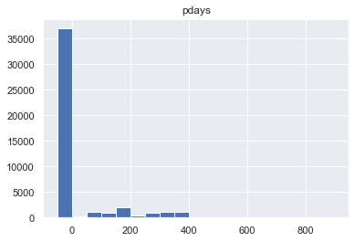

```python
pd.DataFrame.hist(client_data, 'pdays', bins=[50*x-50 for x in range(20)])
```

Most of the values are -1. And -1 only tells us its been > 900 days since last contact - it doesn't tell us when the last contact was. Also, there are hardly any values in the range [400, 900]. So better to convert it to a categorical value.

```python
client_data['recent_contact']=client_data.apply(lambda row: 0 if row.pdays==-1 else 1, axis=1)
```

```python
# Verify if recent_contact values make sense
client_data['recent_contact'].value_counts()
```

```
0    36954
1     8257
Name: recent_contact, dtype: int64
```

```python
# We don't need pdays anymore, so drop.
client_data.drop(columns='pdays', inplace=True)
```

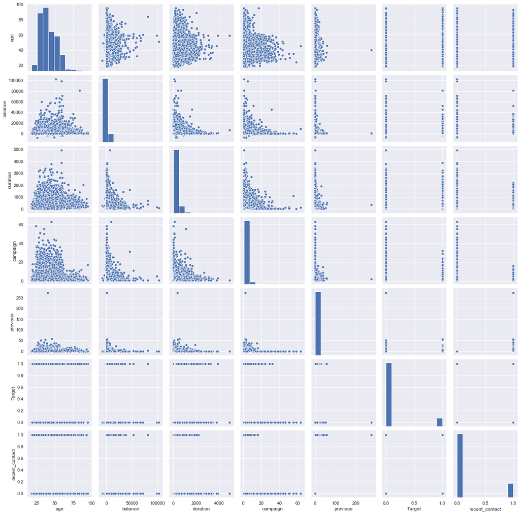

```python
sns.pairplot(client_data)
```

```python
client_data.corr()
```

|  | age | balance | duration | campaign | previous | Target | recent_contact |
| --- | --- | --- | --- | --- | --- | --- | --- |
| age | 1.000000 | 0.097783 | -0.004648 | 0.004760 | 0.001288 | 0.025155 | 0.000753 |
| balance | 0.097783 | 1.000000 | 0.021560 | -0.014578 | 0.016674 | 0.052838 | 0.030213 |
| duration | -0.004648 | 0.021560 | 1.000000 | -0.084570 | 0.001203 | 0.394521 | 0.003590 |
| campaign | 0.004760 | -0.014578 | -0.084570 | 1.000000 | -0.032855 | -0.073172 | -0.107973 |
| previous | 0.001288 | 0.016674 | 0.001203 | -0.032855 | 1.000000 | 0.093236 | 0.532988 |
| Target | 0.025155 | 0.052838 | 0.394521 | -0.073172 | 0.093236 | 1.000000 | 0.167263 |
| recent_contact | 0.000753 | 0.030213 | 0.003590 | -0.107973 | 0.532988 | 0.167263 | 1.000000 |

```
array([[<matplotlib.axes._subplots.AxesSubplot object at 0x0000028BCBAE93C8>]],
      dtype=object)
```

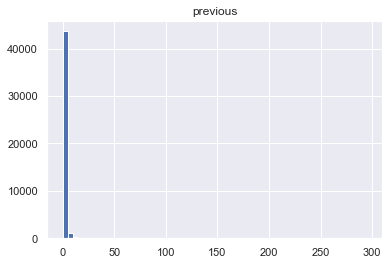

```python
pd.DataFrame.hist(client_data, 'previous', bins=[5*x for x in range(60)])
```

Mostly zero values. Some non-zero values... but large values might create confusion for the model. Let us convert this to a category

```python
client_data['times_contacted']=client_data.apply(lambda row: 'never' if row.previous==0 else ('some' if row.previous<10 else 'many'), axis=1)
```

```python
client_data['times_contacted'].value_counts()
```

```
never    36954
some      7896
many       361
Name: times_contacted, dtype: int64
```

```python
# Ensure categorical columns are treated as such
categories=['job', 'marital', 'education', 'default', 'housing', 'loan', 'contact', 'poutcome']
for c in categories:
    client_data[c]=client_data[c].astype("category")
```

```python
# Let's confirm we have categories where we want them to:
client_data.dtypes
```

```
age                   int64
job                category
marital            category
education          category
default            category
balance               int64
housing            category
loan               category
contact            category
duration              int64
campaign              int64
previous              int64
poutcome           category
Target                int32
recent_contact        int64
times_contacted      object
dtype: object
```

```python
# Ok, one of them is still object - let's convert it.
client_data['times_contacted']=client_data['times_contacted'].astype('category')
client_data.dtypes
```

```
age                   int64
job                category
marital            category
education          category
default            category
balance               int64
housing            category
loan               category
contact            category
duration              int64
campaign              int64
previous              int64
poutcome           category
Target                int32
recent_contact        int64
times_contacted    category
dtype: object
```

```python
# One hot encode the categorical column and remove the observation column
X=pd.get_dummies(client_data.drop(columns=['Target']), drop_first=True)
# And the observation variable..
Y=client_data['Target']
```

```python
X.head()
```

|  | age | balance | duration | campaign | previous | recent_contact | job_blue-collar | job_entrepreneur | job_housemaid | job_management | ... | education_secondary | education_tertiary | default_yes | housing_yes | loan_yes | contact_telephone | poutcome_other | poutcome_success | times_contacted_never | times_contacted_some |
| --- | --- | --- | --- | --- | --- | --- | --- | --- | --- | --- | --- | --- | --- | --- | --- | --- | --- | --- | --- | --- | --- |
| 0 | 58 | 2143 | 261 | 1 | 0 | 0 | 0 | 0 | 0 | 1 | ... | 0 | 1 | 0 | 1 | 0 | 0 | 0 | 0 | 1 | 0 |
| 1 | 44 | 29 | 151 | 1 | 0 | 0 | 0 | 0 | 0 | 0 | ... | 1 | 0 | 0 | 1 | 0 | 0 | 0 | 0 | 1 | 0 |
| 2 | 33 | 2 | 76 | 1 | 0 | 0 | 0 | 1 | 0 | 0 | ... | 1 | 0 | 0 | 1 | 1 | 0 | 0 | 0 | 1 | 0 |
| 3 | 47 | 1506 | 92 | 1 | 0 | 0 | 1 | 0 | 0 | 0 | ... | 1 | 0 | 0 | 1 | 0 | 0 | 0 | 0 | 1 | 0 |
| 4 | 33 | 1 | 198 | 1 | 0 | 0 | 1 | 0 | 0 | 0 | ... | 1 | 0 | 0 | 0 | 0 | 0 | 0 | 0 | 1 | 0 |

5 rows × 28 columns

```python
from sklearn.metrics import confusion_matrix, recall_score, precision_score, f1_score, roc_auc_score,accuracy_score

## function to get confusion matrix in a proper format
def draw_cm( actual, predicted ):
    cm = confusion_matrix( actual, predicted)
    sns.heatmap(cm, annot=True,  fmt='.2f', xticklabels = [0,1] , yticklabels = [0,1] )
    plt.ylabel('Observed')
    plt.xlabel('Predicted')
    plt.show()

def perf_metrics(classifier, X_train, y_train, X_test, y_test, y_predict):
    return {'train_accuracy': classifier.score(X_train,y_train),
            'test_accuracy': classifier.score(X_test, y_test),
            'recall': recall_score(y_test,y_predict),
            'precision': precision_score(y_test,y_predict),
            'f1_score': f1_score(y_test,y_predict),
            'roc_auc_score': roc_auc_score(y_test,y_predict)}
def perf(classifier_name, classifier, X_train, y_train, X_test, y_test, y_predict):
    print(classifier_name+ " Trainig accuracy",classifier.score(X_train,y_train))
    print(classifier_name+ " Testing accuracy",classifier.score(X_test, y_test))
    print(classifier_name + ' Confusion Matrix')
    print(draw_cm(y_test,y_predict))
    print()
    print(classifier_name+" Recall:",recall_score(y_test,y_predict))
    print(classifier_name+" Precision:",precision_score(y_test,y_predict))
    print(classifier_name+ " F1 Score:",f1_score(y_test,y_predict))
    print(classifier_name+ " Roc Auc Score:",roc_auc_score(y_test,y_predict))
```

```python
from sklearn.model_selection import train_test_split

X_train, X_test, y_train, y_test = train_test_split( X, Y, test_size = 0.3, random_state = 42 )
```

```python
# First let's try logistic regression
from sklearn.linear_model import LogisticRegression
logreg=LogisticRegression(max_iter=2000)
logreg.fit(X_train, y_train)
y_predict = logreg.predict(X_test)
```

```
LogisticRegression(C=1.0, class_weight=None, dual=False, fit_intercept=True,
                   intercept_scaling=1, l1_ratio=None, max_iter=2000,
                   multi_class='auto', n_jobs=None, penalty='l2',
                   random_state=None, solver='lbfgs', tol=0.0001, verbose=0,
                   warm_start=False)
```

```
logistic_regression Trainig accuracy 0.8993901475653301
logistic_regression Testing accuracy 0.8989236213506341
logistic_regression Confusion Matrix
```

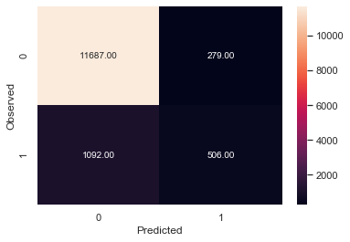

```
None

logistic_regression Recall: 0.3166458072590738
logistic_regression Precision: 0.6445859872611465
logistic_regression F1 Score: 0.42467477968946704
logistic_regression Roc Auc Score: 0.646664872541454
```

```python
perf("logistic_regression", logreg, X_train, y_train, X_test, y_test, y_predict)
```

```
LogisticRegression(C=1.0, class_weight='balanced', dual=False,
                   fit_intercept=True, intercept_scaling=1, l1_ratio=None,
                   max_iter=2000, multi_class='auto', n_jobs=None, penalty='l2',
                   random_state=None, solver='lbfgs', tol=0.0001, verbose=0,
                   warm_start=False)
```

```
logreg_balanced Trainig accuracy 0.825828672544001
logreg_balanced Testing accuracy 0.8250516071955175
logreg_balanced Confusion Matrix
```

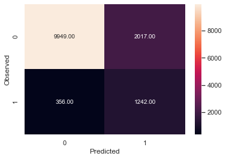

```
None

logreg_balanced Recall: 0.7772215269086358
logreg_balanced Precision: 0.3810984964713102
logreg_balanced F1 Score: 0.5114268066707844
logreg_balanced Roc Auc Score: 0.8043303021472813
```

```python
#Recall is important here. So let's try class_weight=balanced
logreg_balanced=LogisticRegression( class_weight="balanced", max_iter=2000)
logreg_balanced.fit(X_train, y_train)
y_predict=logreg_balanced.predict(X_test)
perf("logreg_balanced", logreg_balanced, X_train, y_train, X_test, y_test, y_predict)
```

We sacrificed precision and accuracy here, but got a good recall score. This is not a great model, but not too bad

```
DecisionTreeClassifier(ccp_alpha=0.0, class_weight='balanced', criterion='gini',
                       max_depth=5, max_features=None, max_leaf_nodes=None,
                       min_impurity_decrease=0.0, min_impurity_split=None,
                       min_samples_leaf=1, min_samples_split=2,
                       min_weight_fraction_leaf=0.0, presort='deprecated',
                       random_state=None, splitter='best')
```

```
decision_tree Trainig accuracy 0.8094606123803204
decision_tree Testing accuracy 0.8063992922441757
decision_tree Confusion Matrix
```

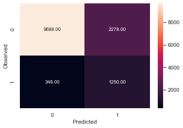

```
None

decision_tree Recall: 0.7822277847309136
decision_tree Precision: 0.3543083900226757
decision_tree F1 Score: 0.4877097151775263
decision_tree Roc Auc Score: 0.7959275310082782
```

```python
# Let's try Decision tree now
# We will once again look for class_weight=balanced for better Recall score
from sklearn.tree import DecisionTreeClassifier
dtree=DecisionTreeClassifier(max_depth=5, class_weight="balanced")
dtree.fit(X_train, y_train)
y_predict = dtree.predict(X_test)
perf("decision_tree", dtree, X_train, y_train, X_test, y_test, y_predict)
```

Like LogisticRegression, this one also suffers from poor precision/accuracy, but has good recall score.

```
BaggingClassifier(base_estimator=None, bootstrap=True, bootstrap_features=False,
                  max_features=1.0, max_samples=1.0, n_estimators=50,
                  n_jobs=None, oob_score=False, random_state=0, verbose=0,
                  warm_start=False)
```

```
Bagging Trainig accuracy 0.9993364299933643
Bagging Testing accuracy 0.8937629017988794
Bagging Confusion Matrix
```

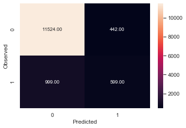

```
None

Bagging Recall: 0.37484355444305384
Bagging Precision: 0.5754082612872238
Bagging F1 Score: 0.45395983327017814
Bagging Roc Auc Score: 0.6689527817343132
```

```python
from sklearn.ensemble import BaggingClassifier
bagging=BaggingClassifier(n_estimators=50, random_state=0)
bagging.fit(X_train, y_train)
y_predict = bagging.predict(X_test)
perf("Bagging", bagging, X_train, y_train, X_test, y_test, y_predict)
```

This has a very poor recall score and the model also overfits. Let's try the same metrics that we used for DecisionTreeClassifier

```
BaggingClassifier(base_estimator=DecisionTreeClassifier(ccp_alpha=0.0,
                                                        class_weight='balanced',
                                                        criterion='gini',
                                                        max_depth=5,
                                                        max_features=None,
                                                        max_leaf_nodes=None,
                                                        min_impurity_decrease=0.0,
                                                        min_impurity_split=None,
                                                        min_samples_leaf=1,
                                                        min_samples_split=2,
                                                        min_weight_fraction_leaf=0.0,
                                                        presort='deprecated',
                                                        random_state=None,
                                                        splitter='best'),
                  bootstrap=True, bootstrap_features=False, max_features=1.0,
                  max_samples=1.0, n_estimators=50, n_jobs=None,
                  oob_score=False, random_state=0, verbose=0, warm_start=False)
```

```
Bagging_balanced Trainig accuracy 0.8043732423294467
Bagging_balanced Testing accuracy 0.8033028605131229
Bagging_balanced Confusion Matrix
```

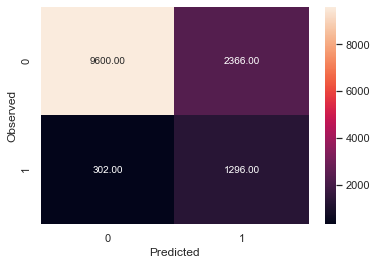

```
None

Bagging_balanced Recall: 0.8110137672090113
Bagging_balanced Precision: 0.3539049699617695
Bagging_balanced F1 Score: 0.4927756653992396
Bagging_balanced Roc Auc Score: 0.8066434371729496
```

```python
from sklearn.ensemble import BaggingClassifier
bagging_balanced=BaggingClassifier(base_estimator=DecisionTreeClassifier(max_depth=5, class_weight="balanced"), n_estimators=50, random_state=0)
bagging_balanced.fit(X_train, y_train)
y_predict = bagging_balanced.predict(X_test)
perf("Bagging_balanced", bagging_balanced, X_train, y_train, X_test, y_test, y_predict)
```

Clearly, this is giving a better recall score with same precision as DecisionTree

```
RandomForestClassifier(bootstrap=True, ccp_alpha=0.0, class_weight=None,
                       criterion='gini', max_depth=None, max_features='auto',
                       max_leaf_nodes=None, max_samples=None,
                       min_impurity_decrease=0.0, min_impurity_split=None,
                       min_samples_leaf=20, min_samples_split=2,
                       min_weight_fraction_leaf=0.0, n_estimators=500,
                       n_jobs=None, oob_score=False, random_state=0, verbose=0,
                       warm_start=False)
```

```
RandomForest Trainig accuracy 0.9064998262078554
RandomForest Testing accuracy 0.8981126511353583
RandomForest Confusion Matrix
```

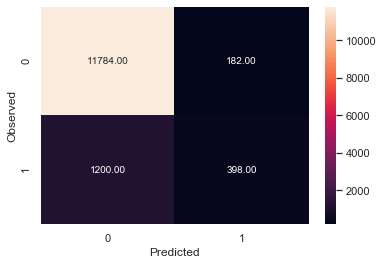

```
None

RandomForest Recall: 0.2490613266583229
RandomForest Precision: 0.6862068965517242
RandomForest F1 Score: 0.3654729109274564
RandomForest Roc Auc Score: 0.6169257828344263
```

```python
from sklearn.ensemble import RandomForestClassifier
rf=RandomForestClassifier(n_estimators=500, min_samples_leaf=20,  random_state=0)
rf.fit(X_train, y_train)
y_predict = rf.predict(X_test)
perf("RandomForest", rf, X_train, y_train, X_test, y_test, y_predict)
```

RandomForest also suffers from an unacceptably low Recall score. Let's try balanced.

```
RandomForestClassifier(bootstrap=True, ccp_alpha=0.0,
                       class_weight='balanced_subsample', criterion='gini',
                       max_depth=None, max_features='auto', max_leaf_nodes=None,
                       max_samples=None, min_impurity_decrease=0.0,
                       min_impurity_split=None, min_samples_leaf=25,
                       min_samples_split=2, min_weight_fraction_leaf=0.0,
                       n_estimators=500, n_jobs=None, oob_score=False,
                       random_state=0, verbose=0, warm_start=False)
```

```
RandomForest_balanced Trainig accuracy 0.831611211173255
RandomForest_balanced Testing accuracy 0.8223975228546152
RandomForest_balanced Confusion Matrix
```

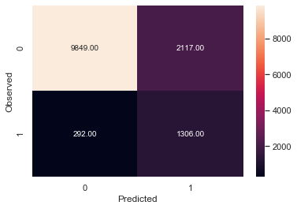

```
None

RandomForest_balanced Recall: 0.8172715894868585
RandomForest_balanced Precision: 0.3815366637452527
RandomForest_balanced F1 Score: 0.5202150965943039
RandomForest_balanced Roc Auc Score: 0.8201768276700547
```

```python
rf_balanced=RandomForestClassifier(n_estimators=500, class_weight="balanced_subsample", min_samples_leaf=25, random_state=0)
rf_balanced.fit(X_train, y_train)
y_predict = rf_balanced.predict(X_test)
perf("RandomForest_balanced", rf_balanced, X_train, y_train, X_test, y_test, y_predict)
```

We can say that Random Forest is the best so far as it is giving good recall with better precision/accuracy.

```
AdaBoostClassifier(algorithm='SAMME.R', base_estimator=None, learning_rate=1.0,
                   n_estimators=50, random_state=0)
```

```
AdaBoost Trainig accuracy 0.8995165418523082
AdaBoost Testing accuracy 0.895532291359481
AdaBoost Confusion Matrix
```

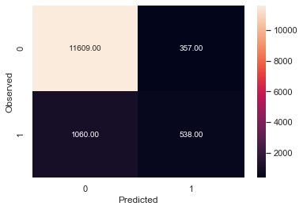

```
None

AdaBoost Recall: 0.33667083854818525
AdaBoost Precision: 0.6011173184357542
AdaBoost F1 Score: 0.4316085038106699
AdaBoost Roc Auc Score: 0.6534181536882662
```

```python
from sklearn.ensemble import AdaBoostClassifier
abc=AdaBoostClassifier(random_state=0)
abc.fit(X_train, y_train)
y_predict =abc.predict(X_test)
perf("AdaBoost", abc, X_train, y_train, X_test, y_test, y_predict)
```

This is not a good result. Let's try DecisionTreeClassifier with balanced option

```
AdaBoostClassifier(algorithm='SAMME.R',
                   base_estimator=DecisionTreeClassifier(ccp_alpha=0.0,
                                                         class_weight='balanced',
                                                         criterion='gini',
                                                         max_depth=3,
                                                         max_features=None,
                                                         max_leaf_nodes=None,
                                                         min_impurity_decrease=0.0,
                                                         min_impurity_split=None,
                                                         min_samples_leaf=20,
                                                         min_samples_split=2,
                                                         min_weight_fraction_leaf=0.0,
                                                         presort='deprecated',
                                                         random_state=None,
                                                         splitter='best'),
                   learning_rate=1.0, n_estimators=50, random_state=0)
```

```
AdaBoost balanced Trainig accuracy 0.8237431668088603
AdaBoost balanced Testing accuracy 0.8123709820112062
AdaBoost balanced Confusion Matrix
```

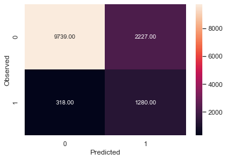

```
None

AdaBoost balanced Recall: 0.8010012515644556
AdaBoost balanced Precision: 0.36498431708012546
AdaBoost balanced F1 Score: 0.5014691478942214
AdaBoost balanced Roc Auc Score: 0.8074453023658815
```

```python
abc_balanced=AdaBoostClassifier(base_estimator=DecisionTreeClassifier(min_samples_leaf=20, max_depth=3, class_weight="balanced"), random_state=0)
abc_balanced.fit(X_train, y_train)
y_predict =abc_balanced.predict(X_test)
perf("AdaBoost balanced", abc_balanced, X_train, y_train, X_test, y_test, y_predict)
```

This is ok. But not great. Random Forest is still the best. Let's try Gradient Boost.

```
GradientBoostingClassifier(ccp_alpha=0.0, criterion='friedman_mse', init=None,
                           learning_rate=0.1, loss='deviance', max_depth=3,
                           max_features=None, max_leaf_nodes=None,
                           min_impurity_decrease=0.0, min_impurity_split=None,
                           min_samples_leaf=1, min_samples_split=2,
                           min_weight_fraction_leaf=0.0, n_estimators=100,
                           n_iter_no_change=None, presort='deprecated',
                           random_state=0, subsample=1.0, tol=0.0001,
                           validation_fraction=0.1, verbose=0,
                           warm_start=False)
```

[output not shown]

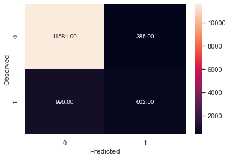

```
None

GradientBoost Recall: 0.376720901126408
GradientBoost Precision: 0.6099290780141844
GradientBoost F1 Score: 0.4657640232108317
GradientBoost Roc Auc Score: 0.6722732033628028
```

```python
from sklearn.ensemble import GradientBoostingClassifier
gbc=GradientBoostingClassifier(random_state=0)
gbc.fit(X_train, y_train)
y_predict =gbc.predict(X_test)
perf("GradientBoost", abc, X_train, y_train, X_test, y_test, y_predict)
```

This is awfully low. There doesn't seem a parameter to tune for Recall. We will leave at this.

```python
# We will now create the dataframe with all the different models and their metrics.
models_metrics = pd.DataFrame ({
    'DecisionTree': perf_metrics(dtree, X_train, y_train, X_test, y_test, dtree.predict(X_test)),
    'LogisticRegression': perf_metrics(logreg_balanced, X_train, y_train, X_test, y_test, logreg_balanced.predict(X_test)),
    'Bagging': perf_metrics(bagging_balanced, X_train, y_train, X_test, y_test, bagging_balanced.predict(X_test)),
    'RandomForest': perf_metrics(rf_balanced, X_train, y_train, X_test, y_test, rf_balanced.predict(X_test)),
    'AdaBoost': perf_metrics(abc_balanced, X_train, y_train, X_test, y_test, abc_balanced.predict(X_test)),
    'GradientBoost': perf_metrics(gbc, X_train, y_train, X_test, y_test, gbc.predict(X_test)),
})
models_metrics.head(10)
```

|  | DecisionTree | LogisticRegression | Bagging | RandomForest | AdaBoost | GradientBoost |
| --- | --- | --- | --- | --- | --- | --- |
| train_accuracy | 0.809461 | 0.825829 | 0.804373 | 0.831611 | 0.823743 | 0.907037 |
| test_accuracy | 0.806399 | 0.825052 | 0.803303 | 0.822398 | 0.812371 | 0.898186 |
| recall | 0.782228 | 0.777222 | 0.811014 | 0.817272 | 0.801001 | 0.376721 |
| precision | 0.354308 | 0.381098 | 0.353905 | 0.381537 | 0.364984 | 0.609929 |
| f1_score | 0.487710 | 0.511427 | 0.492776 | 0.520215 | 0.501469 | 0.465764 |
| roc_auc_score | 0.795928 | 0.804330 | 0.806643 | 0.820177 | 0.807445 | 0.672273 |

Based on the above, it is clear RandomForest is the winner with the best recall score and f1_score. It's precision is also only next to GradientBoost